# Reglas Asociacion #2

José Antonio González Doñas

4/19/2018

Vamos a realizar, uno a uno, todos los pasos descritos en el propio fichero del enunciado.

## 1. Descargar a local el dataset online.csv (en repositorio de GitHub ClassRoom - directorio datasets).

Para hacer uso de un dataset, hay dos opciones:

1. importarlo mediante la interfaz gráfica de RStudio:

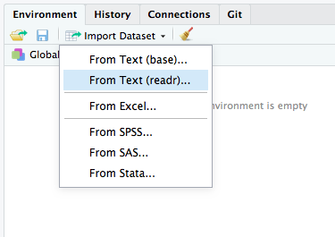

Opción a elegir.

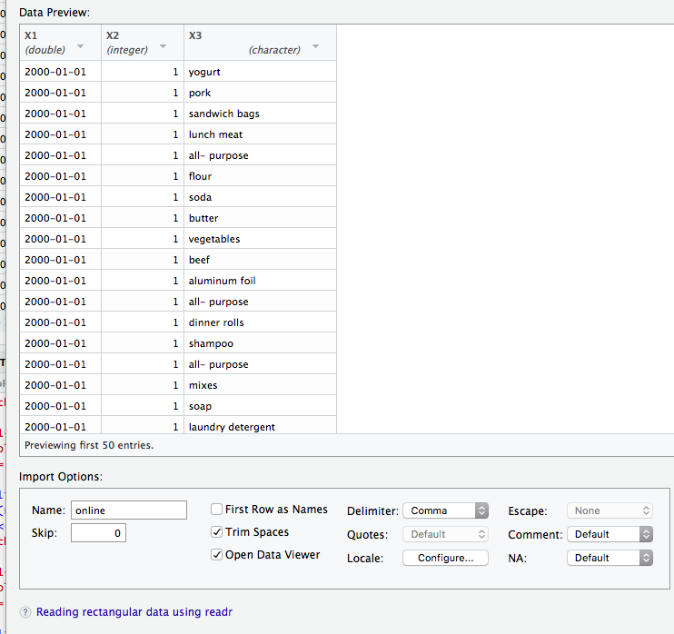

Resultado tras importar.

2. mediante la instrucción read_csv()

```r
library(readr)
online <- read_csv("datasets/online.csv", col_names = FALSE)
```

Nótese que hay que especificar que la primera fila no se corresponde con el nombre de las columnas, de lo contrario se perderá información de esa primera fila. Para ello, se deselecciona la opción “First row as names”.

## 2. Analizar la estructura, tipo,… del dataset.

Para analizar la estructura de un dataset existen varias funciones, entre las cuales, las más típicas y usadas son

- class()
- mode()
- str()

El método **class()** nos devuelve una lista de las clases de las cuales hereda el objeto pasado como argumento. En este caso, como podemos comprobar, **online** hereda de las clases **tbl_df** (table dataframe), **tbl** (table) y **data.frame**(data frame)

```r
class(online)
```

```
## [1] "tbl_df"     "tbl"        "data.frame"
```

La función **mode()**, por otro lado, nos informa del ‘modo de almacenamiento’ del objeto, que en este caso resulta ser de tipo **list**

```r
mode(online)
```

```
## [1] "list"
```

En último lugar, **str** nos muestra la **estructura** del objeto. Esta función acepta una gran variedad de argumentos, pero si la usamos pasándole únicamente el objeto cuya estructura queremos analizar, obtenemos como resultado:

- las clases de las que hereda, al igual que hace la función **class()**
- una muestra de los valores que podemos encontrar en cada uno de sus columnas, campos, o subestructuras, dependiendo del tipo de objeto con el que estemos trabajando.
- un pequeño “sumario”, similar a lo que nos devuelve la función **summary()**, que veremos más adelante, pero con mucho menos detalle.

Es una función muy útil para visualizar estructuras de datos que contienen listas anidadas, aunque como gran parte de las funciones de R, puede ser usada con objetos de cualquier clase.

```r
str(online)
```

```
## Classes 'tbl_df', 'tbl' and 'data.frame':    22343 obs. of  3 variables:
##  $ X1: Date, format: "2000-01-01" "2000-01-01" ...
##  $ X2: int  1 1 1 1 1 1 1 1 1 1 ...
##  $ X3: chr  "yogurt" "pork" "sandwich bags" "lunch meat" ...
##  - attr(*, "spec")=List of 2
##   ..$ cols   :List of 3
##   .. ..$ X1:List of 1
##   .. .. ..$ format: chr ""
##   .. .. ..- attr(*, "class")= chr  "collector_date" "collector"
##   .. ..$ X2: list()
##   .. .. ..- attr(*, "class")= chr  "collector_integer" "collector"
##   .. ..$ X3: list()
##   .. .. ..- attr(*, "class")= chr  "collector_character" "collector"
##   ..$ default: list()
##   .. ..- attr(*, "class")= chr  "collector_guess" "collector"
##   ..- attr(*, "class")= chr "col_spec"
```

En est caso, observamos, como ya mencionamos antes, que **online** es un objeto que hereda de **tbl_df**,**tbl** y **data.frame**, que contiene 22343 registros de 3 variables cada uno, y que la primera columna contiene valores de tipo fecha, la segunda de tipo entero, y la tercera de tipo caracter, entre otra información.

## 3. Analizar significado, estructura, tipo,… de cada columna.

Ya hemos comprobado previamente, gracias a la función **str**, el tipo de cada columna. De todas formas, podemos comprobarlo una a una:

```r
class(online$X1)
```

```
## [1] "Date"
```

```r
class(online$X2)
```

```
## [1] "integer"
```

```r
class(online$X3)
```

```
## [1] "character"
```

**class()** nos indica que la primera columna tiene fechas, la segunda valores enteros y la tercera, cadena de caracteres. Lo mismo podemos hace con el “modo” y su estructura:

```r
mode(online$X1)
```

```
## [1] "numeric"
```

```r
mode(online$X2)
```

```
## [1] "numeric"
```

```r
mode(online$X3)
```

```
## [1] "character"
```

La función modo nos indica por su parte que la información almacenada por las tres columnas es de tipo numérico para las dos primeras, y de caracteres para la tercera, lo cual es lógico: la fecha no deja de ser una información que hace uso de las operaciones numéricas para su tratamiento, más allá de cómo se represente. Las otras dos columnas son de tipo básicos, de ahí que se almacenen directamente como números y caracteres, respectivamente.

Finalmente, con respecto a sus estructuras:

```r
str(online$X1)
```

```
##  Date[1:22343], format: "2000-01-01" "2000-01-01" "2000-01-01" "2000-01-01" "2000-01-01" ...
```

```r
str(online$X2)
```

```
##  int [1:22343] 1 1 1 1 1 1 1 1 1 1 ...
```

```r
str(online$X3)
```

```
##  chr [1:22343] "yogurt" "pork" "sandwich bags" "lunch meat" ...
```

podemos decir a raíz de la información obtenida que:

- las fechas se almacenan con formato **aaaa-mm-dd**
- los números de la segunda columna, se almacenan simplemente con su valor numérico correspondiente
- los valores de la tercera columna se almacenan mediante la cadena de caracteres correspondiente.

En resumen, está claro que en el dataset con el que vamos a trabajar, la información contenida es un conjunto de 22343 registros, donde en cada uno se muestra una fecha, una cantidad, y una etiqueta correspondiente a algo que aún no sabemos lo que es, pero que se aclarará en apartados siguientes y en cualquier caso, podemos inferir, ya que vemos que son nombres de productos de supermercado. En definitiva, podemos deducir que se trata de una base de datos de productos comprados por usuarios identificados por un número, en fechas concretas.

## 4. Comandos para ver las primeras filas y las últimas.

Para ver las primera y últimas filas de una estructura de datos en R, es tan fácil como usar las funciones **head()** y **tail()**, que nos muestran respectivamente, las seis primeras y seis últimas filas de dicha estructura:

```r
head(online)
```

```
## # A tibble: 6 x 3
##   X1            X2 X3
##   <date>     <int> <chr>
## 1 2000-01-01     1 yogurt
## 2 2000-01-01     1 pork
## 3 2000-01-01     1 sandwich bags
## 4 2000-01-01     1 lunch meat
## 5 2000-01-01     1 all- purpose
## 6 2000-01-01     1 flour
```

```r
tail(online)
```

```
## # A tibble: 6 x 3
##   X1            X2 X3
##   <date>     <int> <chr>
## 1 2002-02-25  1138 vegetables
## 2 2002-02-26  1139 soda
## 3 2002-02-26  1139 laundry detergent
## 4 2002-02-26  1139 vegetables
## 5 2002-02-26  1139 shampoo
## 6 2002-02-26  1139 vegetables
```

## 5. Cambiar los nombres de las columnas: Fecha, IDcomprador,ProductoComprado.

Como el dataset original no contiene una fila donde se indique los nombres de columnas, vamos a cambiarlos por unos nombres que sean significativos y ayuden a entender mejor a cualquier persona que los use en adelante a entender qué datos tenemos entre mano.

En primer lugar, nos cercioramos de que no tienen nombre de columnas, o simplemente, vemos qué nombres tienen actualmente, en el caso de que deseemos cambiarlos por otros más adecuados. Para ello usamos la función **colnames()**:

```r
colnames(online)
```

```
## [1] "X1" "X2" "X3"
```

Una forma de cambiarlos muy simple, es asignar a la propiedad **colnames** del dataset **online** los valores que deseamos de forma directa mediante la asignación tradicional en R, es decir, usando el operador **<-**. Así pues, como sabemos que el conjunto de nombres de columnas no es más que un vector de tres elementos, entonces, si ejecutamos:

```r
colnames(online) <- c("Fecha","IDcomprador","ProductoComprado")
colnames(online)
```

```
## [1] "Fecha"            "IDcomprador"      "ProductoComprado"
```

Podemos ver como efectivamente, estos valores han sido modificados en la estructura.

Aparte de haciendo una nueva llamada a la función colnames(), podemos cerciorarnos volviendo a ejecutar head(), ya que a parte de las 6 primeras filas, muestra el nombre de las columnas:

```r
head(online)
```

```
## # A tibble: 6 x 3
##   Fecha      IDcomprador ProductoComprado
##   <date>           <int> <chr>
## 1 2000-01-01           1 yogurt
## 2 2000-01-01           1 pork
## 3 2000-01-01           1 sandwich bags
## 4 2000-01-01           1 lunch meat
## 5 2000-01-01           1 all- purpose
## 6 2000-01-01           1 flour
```

## 6. Hacer un resumen (summary) del dataset y analizar toda la información detalladamente que devuelve el comando.

La función ya antes mencionada **summary** nos devuelve un resumen con datos de gran utilidad a la hora de conocer cuales son las propiedades del conjunto de datos con el que vamos a trabajar. Como se ha dicho anteriormente de otras funciones, ésta puede ser usada con cualquier tipo de objeto de R, y dependiendo del caso devolverá una información u otra, pero siempre útil e interesante.

En nuestro caso, como trabajamos con un **data frame**, nos devolverá información estadística de cada una de las columnas o mejor dicho, listas, que contiene la estructura:

```r
summary(online)
```

```
##      Fecha             IDcomprador     ProductoComprado
##  Min.   :2000-01-01   Min.   :   1.0   Length:22343
##  1st Qu.:2000-05-29   1st Qu.: 292.0   Class :character
##  Median :2001-01-30   Median : 582.0   Mode  :character
##  Mean   :2000-12-21   Mean   : 576.4
##  3rd Qu.:2001-06-21   3rd Qu.: 863.0
##  Max.   :2002-02-26   Max.   :1139.0
```

En este caso, ¿qué información nos ha dado?:

- Las fechas de las compras almacenadas, están comprendidas entre el 1 de enero del año 2000 y el 26 de febrero del año 2002. Se indican también las fechas en las que se dan los cuartiles y la media, pero como suponemos que las compras se reparte de forma más o menos uniforme entre las fechas de inicio y final, esta información no es especialmente interesante (la mediana efectivamente es la fecha intermedia entre las de inicio y final, por ejemplo).
- Hay un total de 1139 identificadores de comprador distintos, esto es, durante esos dos años y dos meses, el negocio vendió productos a 1139 personas distintas, las cuales pudieron, como es lógico hacer más de una compra en ese periodo. De nuevo, los datos de cuartiles no parecen especialmente relevantes, aunque igualmente son indicados por **summary**
- En cuanto a los productos, hay un total de 22343 productos comprados en el periodo que comprende el conjunto de datos, y como es de esperar, todos ellos son representados por cadenas de caracteres.

## 7. Implementar una función que usando funciones vectoriales de R (apply, tapply, sapply,…) te devuelva un primer valor booleano para saber si hay valores NA en alguna columna del dataset. Si así lo fuera devolver sus índices y además sustituirlos por el valor 0.

En primer lugar, y para saber si la función que hagamos en este paso realmente funciona, vamos a ver si existen valores **NA** e nuestro conjunto de datos **online**

```r
length(which(is.na(online$Fecha)))
```

```
## [1] 0
```

```r
length(which(is.na(online$IDcomprador)))
```

```
## [1] 0
```

```r
length(which(is.na(online$ProductoComprado)))
```

```
## [1] 0
```

```r
which(is.na.data.frame(EuStockMarkets))
```

```
## integer(0)
```

Y una tercera forma:

```r
anyNA(online)
```

```
## [1] FALSE
```

Es decir, sabemos de antemano que la función que vamos a generar va a devolver una lista con el valor **FALSE**, indicando que no hay valores **NA**, el *dataframe* **online** tal cual, ya que no contiene valores **NA**, y por último, un vector vacío, ya que no hay posiciones donde encontrar ningún valor **NA**.

En cualquier vamos a crear la función solicitada y probarla con algún dataset que sepamos que tiene valores NA, para demostrar que efectivamente funciona. El código de nuestra función es:

```r
na.in.dataframe <-function(dataframe){

  anyNaValues <- anyNA(dataframe)

  if(!anyNaValues){
    dataframeWithoutNas <- dataframe
    nasPositions <- vector()
  }else{
    m <- as.matrix(dataframe)
    nasPositions <- which(is.na(m))
    m[is.na(m)] <- 0
    dataframeWithoutNas <- as.data.frame(m)
  }

  return(list(any.nas = anyNaValues,
              dataframe.without.nas = dataframeWithoutNas,
              nas.positions = nasPositions))
}
```

Para comprobar su correcto funcionamiento, vamos a insertar valores NA en la colección:

```r
online$Fecha[50] <- NA
online$IDcomprador[60] <- NA
online$ProductoComprado[70] <- NA
df <- na.in.dataframe(online)
df$any.nas
```

```
## [1] TRUE
```

```r
df$nas.positions
```

```
## [1]    50 22403 44756
```

```r
df$dataframe.without.nas[1:70,]
```

```
##         Fecha IDcomprador             ProductoComprado
## 1  2000-01-01           1                       yogurt
## 2  2000-01-01           1                         pork
## 3  2000-01-01           1                sandwich bags
## 4  2000-01-01           1                   lunch meat
## 5  2000-01-01           1                 all- purpose
## 6  2000-01-01           1                        flour
## 7  2000-01-01           1                         soda
## 8  2000-01-01           1                       butter
## 9  2000-01-01           1                   vegetables
## 10 2000-01-01           1                         beef
## 11 2000-01-01           1                aluminum foil
## 12 2000-01-01           1                 all- purpose
## 13 2000-01-01           1                 dinner rolls
## 14 2000-01-01           1                      shampoo
```

[output cut: 56 more lines]

Para los índices, se da una lista de ellos dando por hecho que se usa una estructura de tipo vector, es decir, para cada valor **NA** encontrado, se da su índice considerando que todos los datos de todas las columnas se concatenan. ASí pues, si tenemos un *dataframe* formado por 3 columnas de 1000 valores cada una, y la función nos indica que hay un valor **NA** en la posición 1500, esto significa que el valor 500 de la segunda fila es **NA**. Se podría haber devuelto una lista para cada columna, pero como el enunciado no especifica, se ha resuelto de esta forma.

Antes de continuar, recargamos los datos para desaparezcan los valores **NA** introducidos antes:

```r
library(readr)
online <- read_csv("datasets/online.csv", col_names = FALSE)
colnames(online) <- c("Fecha","IDcomprador","ProductoComprado")
```

## 8. Calcular el número de filas del *dataset*

El número de filas del *dataset* ya lo conocemos gracias a las funciones que hemos ejecutado anteriormente (**str**, **summary**), pero por supuesto existen otras formas de descubrirlo como por ejemplo el método **dim**, que aunque no nos sirve para saber directamente el número de filas, si nos puedo ayudar gracias a lo que ya conocemos de la estrucutra de datos **online**: como es una estructura de tipo tabla, entonces sabemos que está formada por un número de filas y otro de columnas. Si usamos esta función, el resultado es:

```r
dim(online)
```

```
## [1] 22343     3
```

Es decir, nos dice de una forma implícita que está formada por 22343 filas y 3 columnas. Si queremos trabajar con el número de filas, y almacenar ese dato en una variable llamada por ejemplo **numero.filas**, tan solo tendríamos que tomar el primer elemento del vector que devuelve **dim**, de este modo:

```r
numero.filas <- dim(online)[1]
numero.filas
```

```
## [1] 22343
```

Hay que tener cuidado, ya que podemos pensar que la función **length** podría servirnos para obtener el número de filas, pero esto no es así: como **online** es un conjunto de datos estructurado en listas, al ejecutarlo nos devolverá el número de listas que lo forma, que nosotros hemos interpretado previamente como columnas, esto es, nos devolverá que la longitud del conjunto de datos es 3:

```r
length(online)
```

```
## [1] 3
```

De todas formas, si queremos usar **length** para saber el número de filas, no hay problemas: usemoslo para ver cuantos elementos contiene cualquiera de las tres listas que forman la estructura de datos:

```r
length(online$Fecha)
```

```
## [1] 22343
```

```r
length(online$IDcomprador)
```

```
## [1] 22343
```

```r
length(online$ProductoComprado)
```

```
## [1] 22343
```

Es decir, de esta manera está más que confirmado que el *dataset* está formado por 22343 filas.

## 9. Calcula en cuántas fechas distintas se han realizado ventas.

Para el ejercicio 9, 10 y 11, vamos a proceder de la misma manera. La función que nos va a permitir ver cuántos elementos distintos hay dentro de una colección de datos, (en este caso, en una columna dada) es **factor**. Si ejecutamos (uso **head** para que no se muestren todos los elementos, los cuales ocuparían mucho espacio en el documento y se hace molesto de visualizar):

```r
head(factor(online$Fecha))
```

```
## [1] 2000-01-01 2000-01-01 2000-01-01 2000-01-01 2000-01-01 2000-01-01
## 603 Levels: 2000-01-01 2000-01-02 2000-01-03 2000-01-04 ... 2002-02-26
```

obtenemos una lista de todas las fechas existentes en esa columna del *dataset*, pero ya no son tratadas como fechas, sino como **factores**. En la línea final podemos ver que hay 603 niveles, es decir, 603 elementos distintos entre si, o lo que es lo mismo, 603 fechas distintas. Si queremos ver cuáles son esas fechas distintas, tenemos varias formas (uso **head** de nuevo por el mismo motivo):

```r
head(levels(factor(online$Fecha)))
```

```
## [1] "2000-01-01" "2000-01-02" "2000-01-03" "2000-01-04" "2000-01-05"
## [6] "2000-01-06"
```

que como podemos ver, contiene un total de 603 elementos. Si queremos obtener es número, no tenemos que “contarlos”, es tan fácil como usar la función **length**

```r
numero.de.fechas.distintas <- length(levels(factor(online$Fecha)))
numero.de.fechas.distintas
```

```
## [1] 603
```

De cualquier de estas formas, hemos comprobado que hay 603 fechas distintas. Quizás, cuando programemos, la más interesante es la última, ya qu es la que nos permite almacenar en una variable el número buscado, y usarlo para siguientes operaciones.

En los siguientes dos ejercicios, conocidas yas las formas de obtener el número distinto de elementos para cada columna, simplemente ejecutaremos código e indicaremos el número deseado.

## 10. Calcula cuántos compradores distintos hay en el dataset.

Repetimos las instrucciones antes explicadas:

```r
numero.de.compradores.distintos <- length(levels(factor(online$IDcomprador)))
numero.de.compradores.distintos
```

```
## [1] 1139
```

El número de compradores distintos es 1139, aunque gracias a la función **summary** este dato ya lo conocíamos.

## 11. Calcula cuántos productos distintos se han vendido.

Repetimos las instrucciones antes explicadas:

```r
numero.de.productos.distintos <- length(levels(factor(online$ProductoComprado)))
numero.de.productos.distintos
```

```
## [1] 38
```

El número de productos distintos es 38.

## 12. Visualiza con distintos gráficos el dataset.

La visualización gráfica de *datasets* es una muy buena herramienta para conocer, de forma rápida e intuitiva, cómo se relacionan las distintas variables o cómo se distibuyen los datos. En **R** tenemos un gran número de librerías a nuestra disposición para obtener gráficas, así como funciones disponibles en el paquete básico (como **plot**, por ejemplo).

En nuestro caso, nuestro *dataset* es muy básico, y a priori las variables no dan mucho juego, ya que simplemente tenemos un listado de productos comprados, donde se especifica fecha y usuario. Así pues, en este caso sólo podríamos visualizar, por ejemplo:

- productos por fecha (por meses, o día), para detectar qué se compra en ciertas épocas del año
- frecuencia de productos, esto es, obtendríamos información de qué productos son más comprados.

En cualquier caso, **enfrentar unas variables contra otras para buscar patrones no tiene mucho sentido con estos datos**.

En cualquier caso, es posible que antes de poder mostrar gráficas con información de este conjunto de datos, tengamos que realizar algún preprocesado, como por ejemplo agrupación de datos por fecha o por cliente.

En cualquier caso, podemos visualizar datos de las columnas, como por ejemplo:

Histograma de compras por fecha, que nos da una pista de en qué épocas hay más ventas:

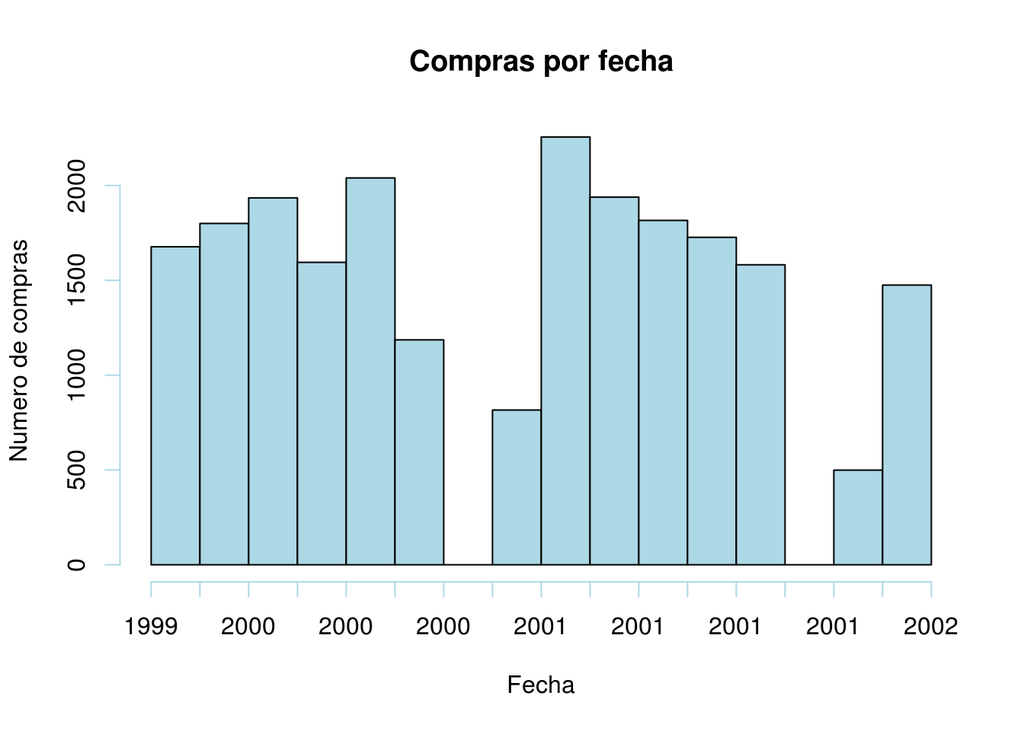

```r
hist(online$Fecha,freq=T,breaks=15,xlab = "Fecha", ylab = "Numero de compras", axes = TRUE, plot = TRUE, labels = FALSE,col = "lightblue",main = "Compras por fecha")
```

Otro ejemplo, sería el de ventas por producto. Para ello, podemos seguir el procedimiento realizado en el apartado número 20, que necesita del uso de otras estructuras de datos que se ven más adelante.

## 13. Usa split para construir a partir del dataset una lista con nombre lista.compra.usuarios en la que cada elemento de la lista es cada comprador junto con todos los productos que ha comprado (de forma similar a lo visto en clase en el recomendador).

Para obtener la lista pedida, tan solo hay que usar el método split con los parámetros deseados, esto es, le indicámos qué datos queremos listar y en base a qué otro parámetro, en este caso queremos listar los productos según el cliente, que a su vez está identificado por el identificador **IDcomprador**:

```r
lista.compra.usuarios <- split(x=online$ProductoComprado,f=online$IDcomprador)
head(lista.compra.usuarios)
```

```
## $`1`
##  [1] "yogurt"            "pork"              "sandwich bags"
##  [4] "lunch meat"        "all- purpose"      "flour"
##  [7] "soda"              "butter"            "vegetables"
## [10] "beef"              "aluminum foil"     "all- purpose"
## [13] "dinner rolls"      "shampoo"           "all- purpose"
## [16] "mixes"             "soap"              "laundry detergent"
## [19] "ice cream"         "dinner rolls"
##
## $`2`
##  [1] "toilet paper"                 "shampoo"
##  [3] "hand soap"                    "waffles"
##  [5] "vegetables"                   "cheeses"
##  [7] "mixes"                        "milk"
##  [9] "sandwich bags"                "laundry detergent"
```

[output cut: 51 more lines]

## 14. Hacer summary de lista.compra.usuarios.

Si usamos la función **summary** con la estructura obtenida en el paso anterior, obtendríamos un pequeño “informe” por cada uno de los elementos de esa lista. Por ello, vamos a aplicarlo solo a los primeros seis elementos:

```r
summary(head(lista.compra.usuarios))
```

```
##   Length Class  Mode
## 1 20     -none- character
## 2 23     -none- character
## 3 31     -none- character
## 4  6     -none- character
## 5 27     -none- character
## 6 28     -none- character
```

Como podemos comprobar, por cada uno de los elementos de la lista obtenida, o dicho de otra forma, por cada uno de los usuarios que han sido registrados en el *dataset* original, se muestra en número de productos que ha comprado (no necesariamente el número de productos distintos), así como la clase (class) y modo (mode) de almacenamiento. En este caso, como los productos se almacenan con su nombre, tenemos que los elementos dentro de cada lista no tienen clase y son almacenados en modo *character*.

## 15. Contar cuántos usuarios hay en la lista lista.compra.usuarios.

Este dato ya lo habíamos calculado en apartados anteriores. No vamos a detenernos mucho en esto por lo tanto, simplemente sabiendo, como ya se ha dicho en el apartado anterior, que la lista que tenemos hace corresponder a cada usuario el conjunto de productos que compra, entonces la función **length** nos va a devolver el número de usuarios que hay en la lista:

```r
length(lista.compra.usuarios)
```

```
## [1] 1139
```

Lo cual, repito, coincide con el dato ya calculado antes: hay 1139 usuarios.

## 16. Detectar y eliminar duplicados en la lista.compra.usuarios (AYUDA: Usar lapply llamando a función unique).

Para detectar y eliminar duplicados, tendríamos quer recorrer cada uno de los elementos de la lista, y aplicarle la función **unique**, que se encarga de devolver un vector con elementos sin repetir. Para conseguir esto, haciendo uso de la potencia de R, tan solo tendríamos que hacer uso de la función **lapply**, la cual se encarga de aplicar la función que le indiquemos, que será **unique**, a cada uno de los elementos de la lista. En primer lugar, para demostrar el funcionamiento, vamos a ver que efectivamente, hay elementos de la lista con productos repetidos, como por ejemplo:

```r
lista.compra.usuarios[5]
```

```
## $`5`
##  [1] "sandwich loaves"  "pasta"            "tortillas"
##  [4] "mixes"            "hand soap"        "toilet paper"
##  [7] "vegetables"       "vegetables"       "paper towels"
## [10] "vegetables"       "flour"            "vegetables"
## [13] "pork"             "poultry"          "eggs"
## [16] "vegetables"       "pork"             "spaghetti sauce"
## [19] "vegetables"       "milk"             "waffles"
## [22] "individual meals" "vegetables"       "dinner rolls"
## [25] "all- purpose"     "soda"             "yogurt"
```

Tiene elementos como “vegetables” repetidos varias veces. Si aplicamos la función, y volvemos a consultar la lista del usuario número 5:

```r
lista.compra.usuarios <- lapply(lista.compra.usuarios,unique)
lista.compra.usuarios[5]
```

```
## $`5`
##  [1] "sandwich loaves"  "pasta"            "tortillas"
##  [4] "mixes"            "hand soap"        "toilet paper"
##  [7] "vegetables"       "paper towels"     "flour"
## [10] "pork"             "poultry"          "eggs"
## [13] "spaghetti sauce"  "milk"             "waffles"
## [16] "individual meals" "dinner rolls"     "all- purpose"
## [19] "soda"             "yogurt"
```

Podemos comprobar que los elementos repetidos han desaparecido (“vegetables” aparece ya tan solo una vez). Por supuesto, esot se ha hecho internamento con todos los usuarios de la lista, es decir, ningún usuario tendrá ahora productos repetidos en su lista.

## 17. Contar cuántos usuarios hay en la lista después de eliminar duplicados.

La operación realizada anteriormente en ningún caso va a modificar el número de usuarios de la lista. En todo caso, si por casualidad dos usuarios distintos hubieran comprado los mismos productos, al ejecutar:

```r
u <- unique(lista.compra.usuarios[1:1139])
length(u)
```

```
## [1] 1139
```

Pero como se puede ver, no varía este número, por lo tanto el número de usuarios que hay en la lista después ede eliminar duplicados no cambia.

## 18. Convertir a tipo de datos transacciones. Guardar en Tlista.compra.usuarios.

Para convertir a tipo de datos **transacciones**, podemos hacer uso de la función **as**, que sirve para hacer conversiones de tipos. Es tan simple como ejecutar lo siguiente no sin antes haber cargado la librería **arules**, ya que ese tipo pertenece a ella y de otra manera el sistema no sabrá a qué tipo se pretende hacer el cambio:

```r
library(arules)
Tlista.compra.usuarios <- as(lista.compra.usuarios,"transactions")
```

Con esto, podemos manipular la información de manera más eficiente, ya que el tipo de datos *transactions* solo almacena, en forma de matriz, los pares para los cuales se cumple un cierto dato. En este caso concreto, para cada usuario, solo tendremos un par que le haga corresponder con el producto comprado. Así pues, al final lo que tenemos en **Tlista.compra.usuarios** será una matriz difusa, con todas la ventajas que ello conlleva, sobre todo a la hora de realizar un sistema de recomendación como el que haremos en los siguientes pasos.

## 19. Hacer inspect de los dos primeros valores de Tlista.compra.usuarios.

Para hacer uso de esta función, antes debemos tener cargada la librería a la que pertenece: **arules** (nosotros lo hicimos en el apartado anterior). Tras ello, podemos ver qué contiene la estructura creada en el apartado anterior. Para elegir los dos primeros valores, podemos usar la sintaxis “corchete”: [1:2]

```r
inspect(Tlista.compra.usuarios[1:2])
```

```
##     items                          transactionID
## [1] {all- purpose,
##      aluminum foil,
##      beef,
##      butter,
##      dinner rolls,
##      flour,
##      ice cream,
##      laundry detergent,
##      lunch meat,
##      mixes,
##      pork,
##      sandwich bags,
##      shampoo,
##      soap,
##      soda,
##      vegetables,
##      yogurt}                                   1
## [2] {aluminum foil,
##      cereals,
##      cheeses,
##      dishwashing liquid/detergent,
##      hand soap,
##      individual meals,
##      laundry detergent,
##      milk,
##      mixes,
##      sandwich bags,
##      shampoo,
##      toilet paper,
##      tortillas,
##      vegetables,
##      waffles,
##      yogurt}                                   2
```

Como se puede comprobar, cada transacción almacena los productos comprados por cada usuario, además sin repeticiones gracias al paso realizado en el apartado número 16.

## 20. Buscar ayuda de itemFrequencyPlot para visualizar las 20 transacciones más frecuentes.

La función **itemFrequencyPlot** nos permite visualizar de forma gráfica, concretamente mediante un diagrama de barras, las frecuencias de cada uno de los *items*, en este caso concreto, productos de supermercado, basado en los datos que tenemos en nuestro objeto de tipo *transactions*. Si consultamos la ayuda de esta función, vemos que existe un parámetro llamado **topN** que hace que se muestren en la gráfica los **n** (con **n** siendo un número entero) elementos con mayor frecuencia o *lift*, si se indica otro parámetro. De esta forma, obtrendremos esos **n** primeros (en este caso, 20 primeros) productos por orden de frecuencia, de **manera descendente según su soporte**. Lo único que tenemos que ejecutar es:

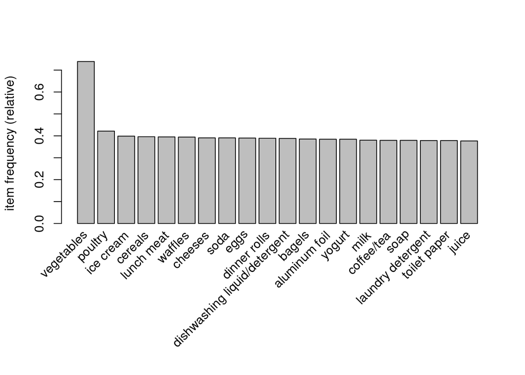

```r
itemFrequencyPlot(Tlista.compra.usuarios, topN=20)
```

Como se puede comprobar, las verduras son el producto más comprado con cierta diferencia, seguidas de aves de corral (*poultry*) y ya, con frecuencias muy parecidas (casi las mismas) propductos como helados, cereales, o carne.

## 21. Generar las reglas de asociación con 80% de confianza y 15% de soporte.

Las reglas de asociación se pueden obtener de forma muy fácil gracias, de nuevo, a la librería **arules**. Tiene varias funciones para conseguir esto, dependiendo del algoritmo que deseemos aplicar: (apriori, eclat). En este caso, vamos a usar **apriori**, la cual acepta parámetros que permiten indicar cual es la confianza y soporte mínimo, concretamente debemos indicarlo dentro del parametro **parameter**, que es una lista en la cual indicar parámetros relativos al propio algoritmo que busca las reglas. En este caso concreto, con ejecutar la siguiente instrucción, sería suficiente:

```r
reglas <- apriori(Tlista.compra.usuarios,parameter=list(supp=0.15, conf=0.8))
```

```
## Apriori
##
## Parameter specification:
##  confidence minval smax arem  aval originalSupport maxtime support minlen
##         0.8    0.1    1 none FALSE            TRUE       5    0.15      1
##  maxlen target   ext
##      10  rules FALSE
##
## Algorithmic control:
##  filter tree heap memopt load sort verbose
##     0.1 TRUE TRUE  FALSE TRUE    2    TRUE
##
## Absolute minimum support count: 170
##
## set item appearances ...[0 item(s)] done [0.00s].
## set transactions ...[38 item(s), 1139 transaction(s)] done [0.00s].
## sorting and recoding items ... [38 item(s)] done [0.00s].
## creating transaction tree ... done [0.00s].
## checking subsets of size 1 2 3 done [0.00s].
## writing ... [22 rule(s)] done [0.00s].
## creating S4 object  ... done [0.00s].
```

Que nos da como resultado un total de 22 reglas:

```r
inspect(reglas)
```

```
##      lhs                               rhs            support confidence     lift count
## [1]  {sandwich loaves}              => {vegetables} 0.2827041  0.8090452 1.094421   322
## [2]  {sugar}                        => {vegetables} 0.2976295  0.8248175 1.115757   339
## [3]  {laundry detergent}            => {vegetables} 0.3090430  0.8167053 1.104783   352
## [4]  {aluminum foil}                => {vegetables} 0.3107989  0.8082192 1.093304   354
## [5]  {yogurt}                       => {vegetables} 0.3195786  0.8310502 1.124188   364
## [6]  {eggs}                         => {vegetables} 0.3266023  0.8378378 1.133370   372
## [7]  {poultry,
##       sugar}                        => {vegetables} 0.1518876  0.8480392 1.147169   173
## [8]  {cereals,
##       laundry detergent}            => {vegetables} 0.1510097  0.8911917 1.205543   172
## [9]  {mixes,
##       poultry}                      => {vegetables} 0.1562774  0.8599034 1.163218   178
## [10] {dishwashing liquid/detergent,
##       eggs}                         => {vegetables} 0.1536435  0.8974359 1.213990   175
## [11] {dishwashing liquid/detergent,
##       poultry}                      => {vegetables} 0.1597893  0.8544601 1.155855   182
## [12] {aluminum foil,
##       yogurt}                       => {vegetables} 0.1527656  0.8613861 1.165224   174
## [13] {dinner rolls,
##       eggs}                         => {vegetables} 0.1562774  0.8989899 1.216092   178
## [14] {dinner rolls,
##       poultry}                      => {vegetables} 0.1615452  0.8288288 1.121183   184
## [15] {eggs,
##       soda}                         => {vegetables} 0.1580334  0.8450704 1.143153   180
## [16] {eggs,
##       yogurt}                       => {vegetables} 0.1571554  0.8994975 1.216779   179
## [17] {poultry,
##       yogurt}                       => {vegetables} 0.1527656  0.8446602 1.142599   174
## [18] {lunch meat,
##       waffles}                      => {vegetables} 0.1571554  0.8523810 1.153043   179
## [19] {lunch meat,
##       poultry}                      => {vegetables} 0.1580334  0.8490566 1.148546   180
## [20] {cheeses,
##       eggs}                         => {vegetables} 0.1501317  0.8860104 1.198534   171
## [21] {cereals,
##       eggs}                         => {vegetables} 0.1510097  0.8643216 1.169195   172
## [22] {eggs,
##       poultry}                      => {vegetables} 0.1553995  0.8805970 1.191211   177
```

## 22. Ver las reglas generadas y ordenalas por lift. Guarda el resultado en una variable nueva.

Las reglas, ya visualizadas en el apartado anterior, pueden ser ordenadas mediante la función **sort**, que permite indicar mediante qué variable ordenar. En este caso, será por *lift*, con lo que tan solo tenemos que ejecutar lo siguiente para almacenarlo en una variable nueva que llamaremos reglasOrdenadasPorLift:

```r
reglasOrdenadasPorLift <- sort(reglas,by="lift")
inspect(reglasOrdenadasPorLift)
```

```
##      lhs                               rhs            support confidence     lift count
## [1]  {eggs,
##       yogurt}                       => {vegetables} 0.1571554  0.8994975 1.216779   179
## [2]  {dinner rolls,
##       eggs}                         => {vegetables} 0.1562774  0.8989899 1.216092   178
## [3]  {dishwashing liquid/detergent,
##       eggs}                         => {vegetables} 0.1536435  0.8974359 1.213990   175
## [4]  {cereals,
##       laundry detergent}            => {vegetables} 0.1510097  0.8911917 1.205543   172
## [5]  {cheeses,
##       eggs}                         => {vegetables} 0.1501317  0.8860104 1.198534   171
## [6]  {eggs,
##       poultry}                      => {vegetables} 0.1553995  0.8805970 1.191211   177
## [7]  {cereals,
##       eggs}                         => {vegetables} 0.1510097  0.8643216 1.169195   172
## [8]  {aluminum foil,
##       yogurt}                       => {vegetables} 0.1527656  0.8613861 1.165224   174
## [9]  {mixes,
##       poultry}                      => {vegetables} 0.1562774  0.8599034 1.163218   178
## [10] {dishwashing liquid/detergent,
##       poultry}                      => {vegetables} 0.1597893  0.8544601 1.155855   182
## [11] {lunch meat,
##       waffles}                      => {vegetables} 0.1571554  0.8523810 1.153043   179
## [12] {lunch meat,
##       poultry}                      => {vegetables} 0.1580334  0.8490566 1.148546   180
## [13] {poultry,
##       sugar}                        => {vegetables} 0.1518876  0.8480392 1.147169   173
## [14] {eggs,
##       soda}                         => {vegetables} 0.1580334  0.8450704 1.143153   180
## [15] {poultry,
##       yogurt}                       => {vegetables} 0.1527656  0.8446602 1.142599   174
## [16] {eggs}                         => {vegetables} 0.3266023  0.8378378 1.133370   372
## [17] {yogurt}                       => {vegetables} 0.3195786  0.8310502 1.124188   364
## [18] {dinner rolls,
##       poultry}                      => {vegetables} 0.1615452  0.8288288 1.121183   184
## [19] {sugar}                        => {vegetables} 0.2976295  0.8248175 1.115757   339
## [20] {laundry detergent}            => {vegetables} 0.3090430  0.8167053 1.104783   352
## [21] {sandwich loaves}              => {vegetables} 0.2827041  0.8090452 1.094421   322
## [22] {aluminum foil}                => {vegetables} 0.3107989  0.8082192 1.093304   354
```

## 23. Elimina todas las reglas redundantes de las dos formas vistas en clase. Calcula el % de reglas redundantes que había usando cada uno de los dos métodos.

Se dice que dos reglas son redundantes si teniendo igual **confianza**, solo difieren en un atributo. La regla con ese atributo extra se considera que no aporta nada, es decir, es redundante y podría ser descartada del conjunto de reglas.

Para eliminar reglas redundantes, efectivamente hay dos métodos:

- mediante la función **is.subset**
- mediante la función **is.redundant**

aunque no se considera que el método que usa la función **is.subset** funcione correctamente, vamos a mostrar como se hace de las dos maneras.

### Método **is.subset**

Lo que haremos, es encontrar qué reglas son subconjunto de otras y almacenarlo en otra variable:

```r
subconjuntos <- is.subset(reglas,reglas)
subconjuntos
```

```
## 22 x 22 sparse Matrix of class "ngCMatrix"
```

```
##    [[ suppressing 22 column names '{sandwich loaves,vegetables}', '{sugar,vegetables}', '{laundry detergent,vegetables}' ... ]]
```

```
##
## {sandwich loaves,vegetables}                      | . . . . . . . . . . .
## {sugar,vegetables}                                . | . . . . | . . . . .
## {laundry detergent,vegetables}                    . . | . . . . | . . . .
## {aluminum foil,vegetables}                        . . . | . . . . . . . |
## {vegetables,yogurt}                               . . . . | . . . . . . |
## {eggs,vegetables}                                 . . . . . | . . . | . .
## {poultry,sugar,vegetables}                        . . . . . . | . . . . .
## {cereals,laundry detergent,vegetables}            . . . . . . . | . . . .
## {mixes,poultry,vegetables}                        . . . . . . . . | . . .
## {dishwashing liquid/detergent,eggs,vegetables}    . . . . . . . . . | . .
## {dishwashing liquid/detergent,poultry,vegetables} . . . . . . . . . . | .
## {aluminum foil,vegetables,yogurt}                 . . . . . . . . . . . |
## {dinner rolls,eggs,vegetables}                    . . . . . . . . . . . .
## {dinner rolls,poultry,vegetables}                 . . . . . . . . . . . .
## {eggs,soda,vegetables}                            . . . . . . . . . . . .
## {eggs,vegetables,yogurt}                          . . . . . . . . . . . .
## {poultry,vegetables,yogurt}                       . . . . . . . . . . . .
## {lunch meat,vegetables,waffles}                   . . . . . . . . . . . .
## {lunch meat,poultry,vegetables}                   . . . . . . . . . . . .
## {cheeses,eggs,vegetables}                         . . . . . . . . . . . .
## {cereals,eggs,vegetables}                         . . . . . . . . . . . .
## {eggs,poultry,vegetables}                         . . . . . . . . . . . .
##
## {sandwich loaves,vegetables}                      . . . . . . . . . .
## {sugar,vegetables}                                . . . . . . . . . .
## {laundry detergent,vegetables}                    . . . . . . . . . .
## {aluminum foil,vegetables}                        . . . . . . . . . .
## {vegetables,yogurt}                               . . . | | . . . . .
## {eggs,vegetables}                                 | . | | . . . | | |
## {poultry,sugar,vegetables}                        . . . . . . . . . .
## {cereals,laundry detergent,vegetables}            . . . . . . . . . .
## {mixes,poultry,vegetables}                        . . . . . . . . . .
## {dishwashing liquid/detergent,eggs,vegetables}    . . . . . . . . . .
## {dishwashing liquid/detergent,poultry,vegetables} . . . . . . . . . .
## {aluminum foil,vegetables,yogurt}                 . . . . . . . . . .
## {dinner rolls,eggs,vegetables}                    | . . . . . . . . .
## {dinner rolls,poultry,vegetables}                 . | . . . . . . . .
## {eggs,soda,vegetables}                            . . | . . . . . . .
## {eggs,vegetables,yogurt}                          . . . | . . . . . .
## {poultry,vegetables,yogurt}                       . . . . | . . . . .
## {lunch meat,vegetables,waffles}                   . . . . . | . . . .
## {lunch meat,poultry,vegetables}                   . . . . . . | . . .
## {cheeses,eggs,vegetables}                         . . . . . . . | . .
## {cereals,eggs,vegetables}                         . . . . . . . . | .
## {eggs,poultry,vegetables}                         . . . . . . . . . |
```

La visualizacion de la propia variable **redundantes**, donde hemos almacenado la información de los subconjuntos encontrados, ya es bastante buena. Hay que tener en cuenta que el resultado no es más que una matriz (dispersa) donde cada conjunto de objetos (*itemsets*) se relaciona con todos los demás *itemsets*, y solo aquellos que son subconjuntos del otro, tendrá el símbolo **|** en su intersección en la matriz. Como es lógico, cada *itemset* estará relacionado consigo mismo, lo que se traduce en que la diagonal tendrá el símbolo **|**. Y por supuesto, si hay subconjuntos, aparecerá más veces, siendo estas otras veces las realmente relevantes. De hecho, podemos comprobar como podemos obviar la parte triangular inferior de la matriz, ya que no contiene ninguna información relevante. Así pues, quedémosnos con esa parte:

```r
matrizRedundantes <- as.matrix(subconjuntos)
matrizRedundantes[lower.tri(matrizRedundantes,diag = T)] <- NA
redundantes <- colSums(matrizRedundantes,na.rm = T) >= 1
which(redundantes)
```

```
##                     {poultry,sugar,vegetables}
##                                              7
##         {cereals,laundry detergent,vegetables}
##                                              8
## {dishwashing liquid/detergent,eggs,vegetables}
##                                             10
##              {aluminum foil,vegetables,yogurt}
##                                             12
##                 {dinner rolls,eggs,vegetables}
##                                             13
##                         {eggs,soda,vegetables}
##                                             15
##                       {eggs,vegetables,yogurt}
##                                             16
##                    {poultry,vegetables,yogurt}
##                                             17
##                      {cheeses,eggs,vegetables}
##                                             20
##                      {cereals,eggs,vegetables}
##                                             21
##                      {eggs,poultry,vegetables}
##                                             22
```

Es decir, hemos:

1. convertido la matriz dispersa en matriz normal
2. hemos hecho que toda la parte triangular inferior, incluida la diagonal, tome valores NA
3. obtenido las reglas que tienen **al menos alguna otra regla** redundante
4. finalmente, mostramos cuales son esas reglas redundantes

```r
length(redundantes)
```

```
## [1] 22
```

```r
reglas.noRedundantes <- reglas[!redundantes]
inspect(reglas.noRedundantes)
```

```
##      lhs                               rhs            support confidence     lift count
## [1]  {sandwich loaves}              => {vegetables} 0.2827041  0.8090452 1.094421   322
## [2]  {sugar}                        => {vegetables} 0.2976295  0.8248175 1.115757   339
## [3]  {laundry detergent}            => {vegetables} 0.3090430  0.8167053 1.104783   352
## [4]  {aluminum foil}                => {vegetables} 0.3107989  0.8082192 1.093304   354
## [5]  {yogurt}                       => {vegetables} 0.3195786  0.8310502 1.124188   364
## [6]  {eggs}                         => {vegetables} 0.3266023  0.8378378 1.133370   372
## [7]  {mixes,
##       poultry}                      => {vegetables} 0.1562774  0.8599034 1.163218   178
## [8]  {dishwashing liquid/detergent,
##       poultry}                      => {vegetables} 0.1597893  0.8544601 1.155855   182
## [9]  {dinner rolls,
##       poultry}                      => {vegetables} 0.1615452  0.8288288 1.121183   184
## [10] {lunch meat,
##       waffles}                      => {vegetables} 0.1571554  0.8523810 1.153043   179
## [11] {lunch meat,
##       poultry}                      => {vegetables} 0.1580334  0.8490566 1.148546   180
```

Quedándonos finalmente, un total de 11 reglas no redundantes.

### Método **is.redundant**

Esta función, del paquete **arules**, nos permite encontrar reglas redundantes indicando simplemente cual es el conjunto de reglas, y adicionalmente, bajo qué parámetro queremos encontrar las reglas redundanes. Tan solo tenemos que ejecutar lo siguiente para obtener un **vector booleano que nos indica qué regla es redundante**:

```r
redundantes2 <- is.redundant(reglas)
length(which(redundantes2))
```

```
## [1] 0
```

Que como podemos ver, nos dice que no hay ninguna regla redundante. Si indicamos alguna medida concreta para realizar la comprobación:

```r
redundantes2 <- is.redundant(reglas,measure="confidence")
length(which(redundantes2))
```

```
## [1] 0
```

```r
redundantes2 <- is.redundant(reglas,measure="improvement")
length(which(redundantes2))
```

```
## [1] 11
```

```r
inspect(reglas[redundantes2])
```

```
##      lhs                                    rhs          support
## [1]  {poultry,sugar}                     => {vegetables} 0.1518876
## [2]  {cereals,laundry detergent}         => {vegetables} 0.1510097
## [3]  {dishwashing liquid/detergent,eggs} => {vegetables} 0.1536435
## [4]  {aluminum foil,yogurt}              => {vegetables} 0.1527656
## [5]  {dinner rolls,eggs}                 => {vegetables} 0.1562774
## [6]  {eggs,soda}                         => {vegetables} 0.1580334
## [7]  {eggs,yogurt}                       => {vegetables} 0.1571554
## [8]  {poultry,yogurt}                    => {vegetables} 0.1527656
## [9]  {cheeses,eggs}                      => {vegetables} 0.1501317
## [10] {cereals,eggs}                      => {vegetables} 0.1510097
## [11] {eggs,poultry}                      => {vegetables} 0.1553995
##      confidence lift     count
## [1]  0.8480392  1.147169 173
## [2]  0.8911917  1.205543 172
## [3]  0.8974359  1.213990 175
## [4]  0.8613861  1.165224 174
## [5]  0.8989899  1.216092 178
## [6]  0.8450704  1.143153 180
## [7]  0.8994975  1.216779 179
## [8]  0.8446602  1.142599 174
## [9]  0.8860104  1.198534 171
## [10] 0.8643216  1.169195 172
## [11] 0.8805970  1.191211 177
```

## 24. Dibuja las reglas ordenadas y no redundantes usando paquete arulesViz. Si son muchas visualiza las 20 primeras.

En primer lugar, deberemos tener cargado el paquete en cuestión:

```r
library(arulesViz)
```

Si visitamos la página de agyuda de este paquete, veremos que hay una serie de funciones que permiten visualizar reglas de asociación y *frequent itemsets*, que son los conjuntos de elementos frecuentes en los que se basan la generación de reglas de asociación. Estas funciones que tenemos a nuestra disposición son:

- **inspectDT**: genera una tabla HTML que permite visualizar y filtrar reglas de forma interactiva
- **plot**: sobrecarga de este ya conocido método para visualizar reglas de asociación, aceptando los parámetros ya usados para otro tipo de estructura de datos
- **plotly_arules**: genera un *scatter plot* de reglas de asociación usando la función **plotly**
- saveAsGraph: almacena un conjunto de reglas como un grafo, en distintos formatos como GraphML, dimacs, o dot.

Vamos a ver distintos ejemplos simples, recomiendo visitar la página de ayuda para poder generar visualizaciones más complejas y a medida de lo que se necesite en cada momento.

### inspectDT

Veamos en este paso, las reglas no redundantes calculadas previamente con el método **is.subset**, ordenadas por confianza:

```r
inspectDT(sort(reglas.noRedundantes,by="conf"))
```

|  | LHS | RHS | support | confidence | lift | count |
| --- | --- | --- | --- | --- | --- | --- |
| [1] | {mixes,poultry} | {vegetables} | 0.156277436347673 | 0.859903381642512 | 1.16321846994159 | 178 |
| [2] | {dishwashing liquid/detergent,poultry} | {vegetables} | 0.159789288849868 | 0.854460093896714 | 1.1558551626465 | 182 |
| [3] | {lunch meat,waffles} | {vegetables} | 0.157155399473222 | 0.852380952380952 | 1.15304264223504 | 179 |
| [4] | {lunch meat,poultry} | {vegetables} | 0.158033362598771 | 0.849056603773585 | 1.14854569085287 | 180 |
| [5] | {eggs} | {vegetables} | 0.326602282704126 | 0.837837837837838 | 1.13336971175451 | 372 |
| [6] | {yogurt} | {vegetables} | 0.319578577699737 | 0.831050228310502 | 1.12418789791646 | 364 |
| [7] | {dinner rolls,poultry} | {vegetables} | 0.161545215100966 | 0.828828828828829 | 1.12118294066038 | 184 |
| [8] | {sugar} | {vegetables} | 0.297629499561018 | 0.824817518248175 | 1.11575671411481 | 339 |
| [9] | {laundry detergent} | {vegetables} | 0.309043020193152 | 0.816705336426914 | 1.10478310948961 | 352 |
| [10] | {sandwich loaves} | {vegetables} | 0.28270412642669 | 0.809045226130653 | 1.09442103629788 | 322 |

[output cut: 1 more lines]

Como se puede ver, se genera una tabla muy interesante, al estilo de las que podemos ver en páginas web, que permiten reordenar columnas, hacer búsquedas por cada una de ellas, y paginar los elementos para que la tabla no sea excesivamente grande o bien para mostrar todos los elementos de una vez. Además, si se hace uso de ella en un documento **rmarkdown**, del cual se va a generar un HTML, es muy interesante ya que en el documento resultante vamos a poder interactuar con la tabla, manteniendo ésta toda su funcionalidad.

### plot

Esta función nos permite ver ciertas propeidades de las reglas de asociación. Por ejemplo, con los parámetros por defecto, nos permite ver para el conjunto de reglas, el soporte de cada una de ellas frente a su confianza. Este tipo de gráfica la hemos visto ya con otras estructuras, y sabemos que para un tercer parámetro, se usa una escala de colores, que se indica a la derecha (en este caso, para el *lift*). Si indicamos que queremos interactividad, podemos inspeccionar, filtrar y hacer *zoom*, aunque esta opción no parece funcionar en los documentos **rmarkdown**. Probemóslo con las reglas redundanetes que en este caso no tiene sentido ordenarlas ya que se nos va a motrar un gráfico donde el orden en que le pasemos las reglas no interfiere en el resultado:

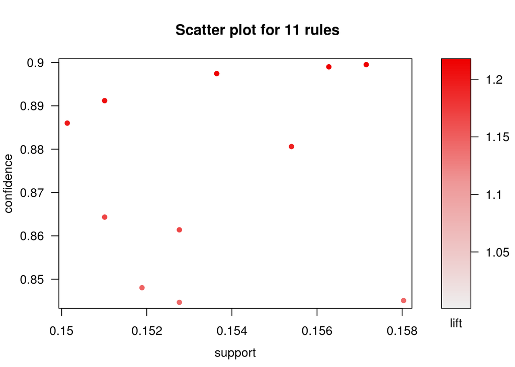

```r
plot(reglas[redundantes])
```

Si quisieramos la interactividad antes mencionada:

```r
plot(reglas, engine = "interactive")
```

### plotly_arules

Esta función nos permite generar gráficas de tipo *scatterplot*, *two-key plot* y *matrix*, y permite una alta personalización del gráfico resultante, indicando tamaño de marcadores, colores, etc:

Además, permite guardar la gráfica obtenida como página html mediante:

```r
p <- plotly_arules(rules)
htmlwidgets::saveWidget(p, "arules.html", selfcontained = FALSE)
browseURL("arules.html")
```

En mi caso, la función no parece funcionar pese a cargar la librería **plotly**, que parece ser necesaria.

### saveAsGraph

Aunque no es un método de visualización como los anteriores, lo comento ya que pertenece a **arulesViz**: ésta función permite almacenar un conjunto de reglas en un documento **XML** en su comportamiento por defecto, que puede ser útil a la hora de portar los datos y ser usados por parte de otras aplicaciones. También puede ser almacenado en otros formatos: “edgelist”, “dimacs”, “gml”, “dot”

```r
saveAsGraph(reglas, "reglas.graphml")
```

## 25. MUY IMPORTANTE: Investigar algún otro paquete R relacionado con reglas de asociación (no visto en clase). Explicar su uso con un dataset y con ejemplos.

Uno de los paquetes relacionados con las reglas de asociación que aparecen con más frecuencia cuando se hace una búsqueda por internet es arulesCBA, que es un paquete que permite construir clasificadores, usando algoritmos de asociación, que nos permitan clasificar datos.

Para este ejemplo, necesitaremos por supuesto tener instalada y cargada la librería **arulesCBA** y además, para poder mostrar ejemplos, usaremos el *dataset* **iris** (veremos los ejemplos de la documentación, ya que pruebas con otros datos me han dado errores).

```r
library(arulesCBA)
```

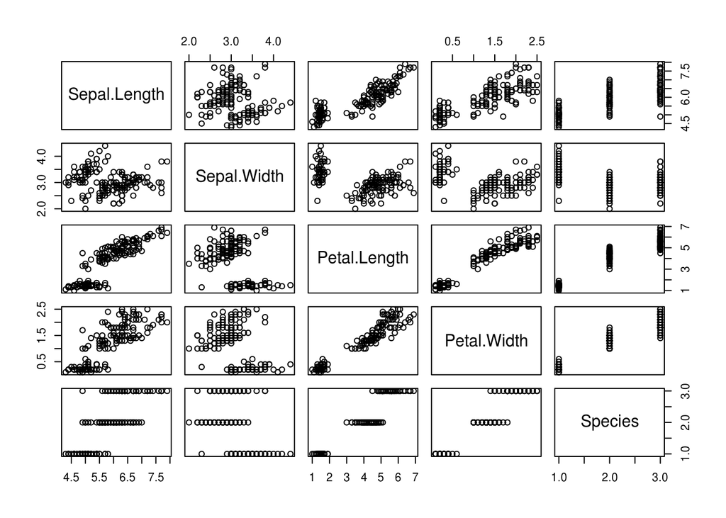

```r
data("iris")
attach(iris)
pairs(iris)
```

Como se puede ver, puede ser interesante analizar **Petal.Length** con **Petal.Width** (población) ya que parecen tener una relación clara.

Una de las funciones disponibles es bCBA, que permite obtener clasificadores de, en este caso, flores según los datos disponibles, y haciendo uso de reglas de asociación de manera interna. Así pues, con:

```r
classifier <- bCBA(Species ~ ., data = iris, supp = 0.05, conf = 0.9, lhs.support = TRUE)
predict(classifier,iris)
```

```
##   [1] setosa     setosa     setosa     setosa     setosa     setosa
##   [7] setosa     setosa     setosa     setosa     setosa     setosa
##  [13] setosa     setosa     setosa     setosa     setosa     setosa
##  [19] setosa     setosa     setosa     setosa     setosa     setosa
##  [25] setosa     setosa     setosa     setosa     setosa     setosa
##  [31] setosa     setosa     setosa     setosa     setosa     setosa
##  [37] setosa     setosa     setosa     setosa     setosa     setosa
##  [43] setosa     setosa     setosa     setosa     setosa     setosa
##  [49] setosa     setosa     versicolor versicolor versicolor versicolor
##  [55] versicolor versicolor versicolor versicolor versicolor versicolor
##  [61] versicolor versicolor versicolor versicolor versicolor versicolor
##  [67] versicolor versicolor versicolor versicolor virginica  versicolor
##  [73] setosa     versicolor versicolor versicolor setosa     versicolor
##  [79] versicolor versicolor versicolor versicolor versicolor versicolor
##  [85] versicolor versicolor versicolor versicolor versicolor versicolor
##  [91] versicolor versicolor versicolor versicolor versicolor versicolor
##  [97] versicolor versicolor versicolor versicolor virginica  virginica
## [103] virginica  virginica  virginica  virginica  versicolor virginica
## [109] virginica  virginica  virginica  virginica  virginica  virginica
## [115] virginica  virginica  virginica  virginica  virginica  versicolor
## [121] virginica  virginica  virginica  virginica  virginica  virginica
## [127] virginica  virginica  virginica  versicolor virginica  virginica
## [133] virginica  setosa     versicolor virginica  virginica  virginica
## [139] virginica  virginica  virginica  virginica  virginica  virginica
## [145] virginica  virginica  virginica  virginica  virginica  virginica
## Levels: setosa versicolor virginica
```

hemos obtenido una predicción en la que, a partir de los datos obtenidos, la especia a la que se corresponden dichos datos. Para poder comparar, los datos orignales son:

```r
iris$Species
```

```
##   [1] setosa     setosa     setosa     setosa     setosa     setosa
##   [7] setosa     setosa     setosa     setosa     setosa     setosa
##  [13] setosa     setosa     setosa     setosa     setosa     setosa
##  [19] setosa     setosa     setosa     setosa     setosa     setosa
##  [25] setosa     setosa     setosa     setosa     setosa     setosa
##  [31] setosa     setosa     setosa     setosa     setosa     setosa
##  [37] setosa     setosa     setosa     setosa     setosa     setosa
##  [43] setosa     setosa     setosa     setosa     setosa     setosa
##  [49] setosa     setosa     versicolor versicolor versicolor versicolor
##  [55] versicolor versicolor versicolor versicolor versicolor versicolor
##  [61] versicolor versicolor versicolor versicolor versicolor versicolor
##  [67] versicolor versicolor versicolor versicolor versicolor versicolor
##  [73] versicolor versicolor versicolor versicolor versicolor versicolor
##  [79] versicolor versicolor versicolor versicolor versicolor versicolor
##  [85] versicolor versicolor versicolor versicolor versicolor versicolor
##  [91] versicolor versicolor versicolor versicolor versicolor versicolor
##  [97] versicolor versicolor versicolor versicolor virginica  virginica
## [103] virginica  virginica  virginica  virginica  virginica  virginica
## [109] virginica  virginica  virginica  virginica  virginica  virginica
## [115] virginica  virginica  virginica  virginica  virginica  virginica
## [121] virginica  virginica  virginica  virginica  virginica  virginica
## [127] virginica  virginica  virginica  virginica  virginica  virginica
## [133] virginica  virginica  virginica  virginica  virginica  virginica
## [139] virginica  virginica  virginica  virginica  virginica  virginica
## [145] virginica  virginica  virginica  virginica  virginica  virginica
## Levels: setosa versicolor virginica
```

```r
classifier
```

```
## CBA Classifier Object
## Class: Species=setosa, Species=versicolor, Species=virginica
## Default Class: Species=setosa
## Number of rules: 50
## Classification method: weighted (weighted)
## Description: Transaction boosted associative classifier with
##      support=0.05 confidence=0.9 gamma=0.05 cost=10
```

De un modo muy parecido trabaja la función **CBA**, que tiene incluso los mismos parámetros, pero internamente trabaja de forma diferente.

Por último, otra función muy intersante es **discretizeDF.supervised** que permite convertir variables continuas en discretas, esto es, en factores, que son adecuados para el minado mediante las reglas de asociación.

```r
summary(iris)
```

```
##   Sepal.Length    Sepal.Width     Petal.Length    Petal.Width
##  Min.   :4.300   Min.   :2.000   Min.   :1.000   Min.   :0.100
##  1st Qu.:5.100   1st Qu.:2.800   1st Qu.:1.600   1st Qu.:0.300
##  Median :5.800   Median :3.000   Median :4.350   Median :1.300
##  Mean   :5.843   Mean   :3.057   Mean   :3.758   Mean   :1.199
##  3rd Qu.:6.400   3rd Qu.:3.300   3rd Qu.:5.100   3rd Qu.:1.800
##  Max.   :7.900   Max.   :4.400   Max.   :6.900   Max.   :2.500
##        Species
##  setosa    :50
##  versicolor:50
##  virginica :50
##
##
##
```

```r
iris.disc <- discretizeDF.supervised(Species ~ ., iris)
summary(iris.disc)
```

```
##       Sepal.Length      Sepal.Width      Petal.Length      Petal.Width
##  [-Inf,5.55):59    [-Inf,2.95):57   [-Inf,2.45):50    [-Inf,0.8) :50
##  [5.55,6.15):36    [2.95,3.35):56   [2.45,4.75):45    [0.8,1.75) :54
##  [6.15, Inf]:55    [3.35, Inf]:37   [4.75, Inf]:55    [1.75, Inf]:46
##        Species
##  setosa    :50
##  versicolor:50
##  virginica :50
```

Claramento se ve la diferencia, donde anteriormente los datos son tratados como los de una variable continua y tras discretizar, se tratan como variables discretizadas haciendo uso de la formula pasada como primer parámetro, en este caso **Species ~ .**, que relaciona la especie con todas las demas variables.

Se deja como opción al lector el investigar el resto de funciones de esta librería, entre las que se encuentran **wCBA**, **mineCARs**, y **CBA.object**.